# Fit parameters in PBPK model

Metrum Research Group, LLC

# Packages and setup

```r
library(readr)
library(dplyr)
library(mrgsolve)
library(minqa)
library(magrittr)
library(tidyr)
library(ggplot2)
source("src/functions.R")

knitr::opts_chunk$set(comment = '.', message = FALSE, warning = FALSE)

set.seed(10101)
```

**Quantitative Analyses of Hepatic OATP-Mediated Interactions Between Statins and Inhibitors Using PBPK Modeling With a Parameter Optimization Method**

- T Yoshikado, K Yoshida, N Kotani, T Nakada, R Asaumi, K Toshimoto, K Maeda, H Kusuhara and Y Sugiyama
- CLINICAL PHARMACOLOGY & THERAPEUTICS | VOLUME 100 NUMBER 5 | NOVEMBER 2016
- https://www.ncbi.nlm.nih.gov/pubmed/27170342

# Read some (digitized) data

- Example taken from figure 4a from the publication
- Using this as example data to fit

```r
data.file <- file.path("data", "fig4a.csv")

data <- read_csv(data.file) %>%
  mutate(profile = NULL, type=ID, typef=typef(ID))
```

- The goal is to fit the pitavastatin data either alone (left) or in combination with cyclosporin administered 1 hour before the pitavastatin

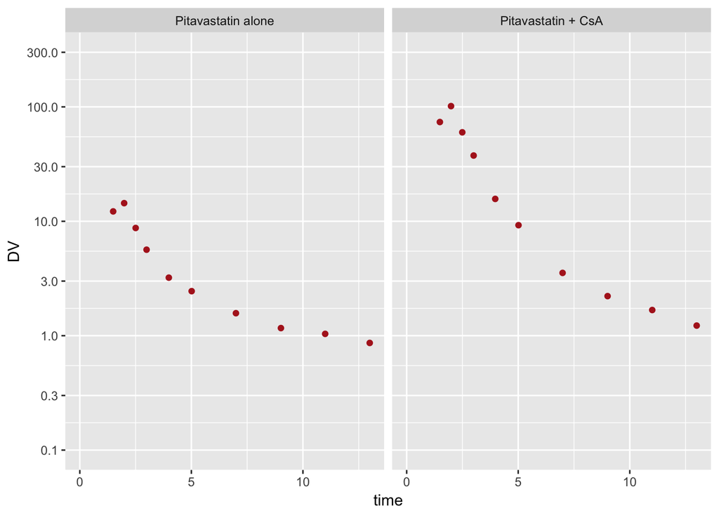

```r
ggplot(data=data,aes(time,DV)) +
  geom_point(col="firebrick") +
  facet_wrap(~typef) +
  scale_y_continuous(trans="log", limits=c(0.1,300), breaks=logbr())
```

# Some data assembly

- Pick out the doses and the observations

```r
dose <- filter(data,evid==1) %>% mutate(typef=NULL)

dose
```

```
. # A tibble: 3 x 7
.      ID  time    DV  evid   amt   cmt  type
.   <int> <dbl> <dbl> <int> <int> <int> <int>
. 1     2     0    -1     1  2000     2     2
. 2     2     1    -1     1    30     1     2
. 3     1     1    -1     1    30     1     1
```

```r
yobs <- filter(data,evid==0) %>% dplyr::select(DV) %>% unlist %>% unname

yobs
```

```
.  [1]  73.707 101.538  59.936  37.558  15.684   9.243   3.538   2.217
.  [9]   1.676   1.225  12.198  14.400   8.736   5.644   3.215   2.450
. [17]   1.572   1.165   1.037   0.864
```

```r
data %<>% dplyr::select(-typef)
```

# Our objective function

- Least squares objective function
- Weighted by the observations

```r
wss <- function(dv, pred, par=NULL) {
  sum(((dv-pred)/dv)^2)
}
```

# Read in the model

- Check out the model / data with a quick simulation
- We’re only interested in `CP`, the pitavastatin concentration

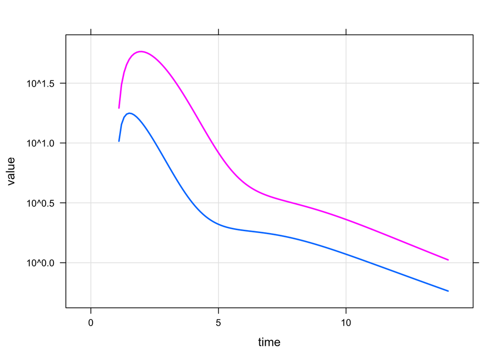

```r
mod <- mread("yoshikado","model") %>%
  update(end=14, delta=0.1) %>% Req(CP) %>% obsonly

mod %>%
  mrgsim(data=dose,obsaug=TRUE) %>%
  plot(CP~.,scales=list(y=list(log=TRUE)))
```

# Prediction function

- Let’s go through step by step what each line is doing for us

```r
pred <- function(p, .data, yobs=NULL, pred=FALSE) {

  .par <- lapply(p,exp) %>% setNames(names(theta))

  .mod <- param(mod,.par)

  if(pred) {
    out <- mrgsim(.mod,data=.data,carry.out="type")
    return(as_data_frame(out))
  }

  out <- mrgsim(.mod, data=.data, obsonly=TRUE, Req="CP")

  return(wss(yobs,out$CP))

  #return(-1*sum(dnorm(log(yobs),log(out$CP),.par$sigma,log=TRUE)))

}
```

# Fit with `minqa::newuoa`

- These appear to be the parameters that the authors are fitting

```r
theta <- log(c(fbCLintall = 1.2, ikiu = 1.2,
               fbile = 0.9, ka = 0.1, ktr = 0.1))

control <- list(iprint=25)

fit <- newuoa(theta, pred,.data=data, yobs=yobs,control=control)
```

```
. npt = 7 , n =  5
. rhobeg =  0.460517 , rhoend =  4.60517e-07
. start par. =  0.1823216 0.1823216 -0.1053605 -2.302585 -2.302585 fn =  11.02654
. rho:    0.046 eval:   8 fn:      7.75648 par:-0.278195 0.182322 -0.105361 -2.30259 -2.30259
.  25:     5.9761224: -0.384231 0.0362187 0.00414904 -1.21552 -2.32950
.  50:     5.3746414: -0.308474 0.648869 0.292187 -0.906502 -1.96730
. rho:   0.0046 eval:  51 fn:      5.32508 par:-0.353181 0.655977 0.284323 -0.909374 -1.96612
.  75:     5.2022726: -0.320546 -0.533898 -0.274200 -0.921442 -1.67556
. 100:    0.79406980: -0.303094 -4.35907 -1.16376 -0.0265183 -0.471256
. 125:    0.70299019: -0.243131 -4.45334 -1.09792 -0.0545418 -0.415231
. 150:    0.68798052: -0.212374 -4.51928 -1.07945 -0.0326458 -0.400875
. rho:  0.00046 eval: 173 fn:     0.686147 par:-0.203775 -4.51280 -1.06756 -0.0161248 -0.374583
. 175:    0.68615202: -0.203091 -4.51357 -1.06733 -0.0158995 -0.373252
. 200:    0.68607670: -0.204148 -4.51473 -1.06758 -0.0111999 -0.371226
. rho:  4.6e-05 eval: 203 fn:     0.686077 par:-0.204225 -4.51452 -1.06760 -0.0114243 -0.371555
. rho:  4.6e-06 eval: 213 fn:     0.686076 par:-0.204215 -4.51458 -1.06764 -0.0114134 -0.371594
. rho:  4.6e-07 eval: 222 fn:     0.686076 par:-0.204215 -4.51458 -1.06764 -0.0114134 -0.371594
. 225:    0.68607653: -0.204215 -4.51458 -1.06764 -0.0114135 -0.371595
. At return
. eval: 231 fn:     0.68607649 par: -0.204215 -4.51458 -1.06764 -0.0114134 -0.371594
```

```r
fit$par <- setNames(fit$par,names(theta))
```

# Get some predictions to look at how the fit went

- Predictions with the final estimates
- Predications with the initial estimates
- Observed data to overlay

```r
df_pred <- pred(fit$par,dose,pred=TRUE) %>% mutate(type = typef(type))
df_init <- pred(theta,dose,pred=TRUE) %>% mutate(type = typef(type))
df_obs <- mutate(data, type=typef(type))
```

## Plot

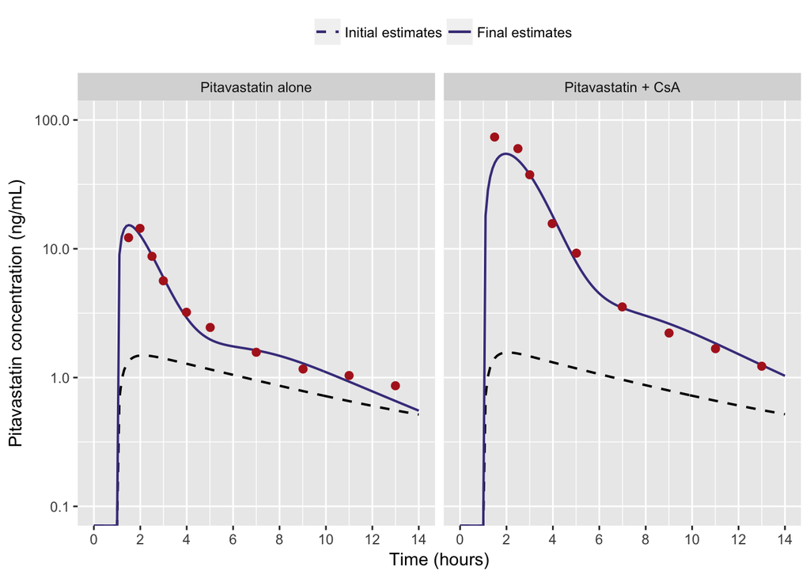

```r
ggplot(data=df_pred) +
  geom_line(data=df_init,aes(time,CP,lty="A"), col="black", lwd=0.7) +
  geom_line(aes(time,CP,lty="B"),col="darkslateblue",lwd=0.7) +
  geom_point(data=df_obs,aes(time,DV),col="firebrick",size=2) +
  facet_wrap(~type) +
  scale_y_continuous(trans="log",breaks=10^seq(-4,4),
                     limits=c(0.1,100),
                     "Pitavastatin concentration (ng/mL)") +
  scale_x_continuous(name="Time (hours)", breaks=seq(0,14,2)) +
  scale_linetype_manual(values= c(2,1),
                        labels=c("Initial estimates", "Final estimates"), name="") +
  theme(legend.position="top")
```

## The final objecteive function value and estimates

```r
pred(fit$par,.data=data,yobs=yobs)
```

```
. [1] 0.6860765
```

```r
exp(fit$par)
```

```
. fbCLintall       ikiu      fbile         ka        ktr
. 0.81528670 0.01094824 0.34381934 0.98865149 0.68963400
```

# Fit with `mrgsolvetk` and `optimhelp`

```r
library(mrgsolvetk)

library(optimhelp)

par <- parset(log_par("fbCLintall",1.2),
              log_par("ikiu", 1.2),
              logit_par("fbile", 0.8),
              log_par("ka", 0.1),
              log_par("ktr", 0.1))
```

```r
par
```

```
.        name value transf tr fx
.  fbCLintall   1.2    log  u
.        ikiu   1.2    log  u
.       fbile   0.8  logit  u
.          ka   0.1    log  u
.         ktr   0.1    log  u
```

```r
initials(par)
```

```
. fbCLintall       ikiu      fbile         ka        ktr
.  0.1823216  0.1823216  1.3862944 -2.3025851 -2.3025851
```

## Then fit with “CG” method in `stats::optim`

```r
fitt <- fit_optim(mod, data, pred="CP", ofv=wss, par=par, method="CG",
                 control=list(trace=10))
```

```r
coef(fitt$pars)

fitt$value
```

[output not shown]

# DEoptim

“Performs evolutionary global optimization via the Differential Evolution algorithm.”

```r
library(RcppDE)

lower <- rep(-6,length(theta)) %>% setNames(names(theta))
upper <- rep(4,length(theta)) %>% setNames(names(theta))

set.seed(330303)
decontrol <- DEoptim.control(NP=10*length(theta), CR=0.925, F=0.85,
                           itermax=100, storepopfrom=0)

fit2 <- DEoptim(fn=pred, lower=lower,upper=upper, control=decontrol,
                .data=data, yobs=yobs)

data.frame(initial = exp(theta),
           DE = exp(fit2$optim$bestmem),
           newuoa  = exp(fit$par),
           CG = exp(fitt$par)) %>% signif(3)
```

[output not shown]

## DA for the plot

```r
pops <- lapply(fit2$member$storepop, as.data.frame)
hx <- bind_rows(pops)
hx <- mutate(hx, iteration=rep(1:decontrol$itermax,each=decontrol$NP))
hx <- mutate(hx, pop = rep(1:decontrol$NP, time=decontrol$itermax))
hxm <- gather(hx, variable, value, 1:5) %>% mutate(value = exp(value))
best <- as_data_frame(fit2$member$bestmemit) %>%
  mutate(iteration = 1:decontrol$itermax)
bestm <- gather(best,variable,value,1:5) %>% mutate(value = exp(value))
```

```r
ggplot(data=hxm) +
  geom_line(aes(iteration,value,group=pop),col="darkslateblue") +
  geom_line(data=bestm,aes(iteration,value),col="orange",lwd=1) +
  scale_y_continuous(trans="log", breaks=10^seq(-4,4), name="Parameter value") +
  facet_wrap(~variable, ncol=2, scales="free_y")
```

[output not shown]